# Class-12-PlottingDataInPython

```python
import pandas as pd
```

Here we can import our pickled data

```python
df = pd.read_pickle("simulated_data.pkl")
df.head()
```

|  | Incongruent Response | Congruent Response | Incongruent RT | Congruent RT | Apple Preference | Crab Preference |
| --- | --- | --- | --- | --- | --- | --- |
| 0 | incorrect | correct | 4.512119 | 3.401761 | 78.795446 | 5.210716 |
| 1 | incorrect | correct | 4.630665 | 3.049635 | 64.532171 | 10.051328 |
| 2 | incorrect | correct | 3.451311 | 3.544197 | 49.320005 | 38.124945 |
| 3 | incorrect | correct | 4.139284 | 1.553025 | 103.676105 | 51.733424 |
| 4 | incorrect | correct | 2.565913 | 3.495347 | 86.422666 | 28.784980 |

When reading our excel file or csv file we need to specify that the first column is the index using `index_col=0`.

```python
df = pd.read_excel("simulated_data.xlsx", index_col=0)
df.head()
```

|  | Incongruent Response | Congruent Response | Incongruent RT | Congruent RT | Apple Preference | Crab Preference |
| --- | --- | --- | --- | --- | --- | --- |
| 0 | incorrect | correct | 4.512119 | 3.401761 | 78.795446 | 5.210716 |
| 1 | incorrect | correct | 4.630665 | 3.049635 | 64.532171 | 10.051328 |
| 2 | incorrect | correct | 3.451311 | 3.544197 | 49.320005 | 38.124945 |
| 3 | incorrect | correct | 4.139284 | 1.553025 | 103.676105 | 51.733424 |
| 4 | incorrect | correct | 2.565913 | 3.495347 | 86.422666 | 28.784980 |

Look what happens when we don't specify the index column

```python
df = pd.read_csv("simulated_data.csv")
df.head()
```

|  | Unnamed: 0 | Incongruent Response | Congruent Response | Incongruent RT | Congruent RT | Apple Preference | Crab Preference |
| --- | --- | --- | --- | --- | --- | --- | --- |
| 0 | 0 | incorrect | correct | 4.512119 | 3.401761 | 78.795446 | 5.210716 |
| 1 | 1 | incorrect | correct | 4.630665 | 3.049635 | 64.532171 | 10.051328 |
| 2 | 2 | incorrect | correct | 3.451311 | 3.544197 | 49.320005 | 38.124945 |
| 3 | 3 | incorrect | correct | 4.139284 | 1.553025 | 103.676105 | 51.733424 |
| 4 | 4 | incorrect | correct | 2.565913 | 3.495347 | 86.422666 | 28.784980 |

See the difference?

```python
df = pd.read_csv("simulated_data.csv", index_col=0)
df.head()
```

|  | Incongruent Response | Congruent Response | Incongruent RT | Congruent RT | Apple Preference | Crab Preference |
| --- | --- | --- | --- | --- | --- | --- |
| 0 | incorrect | correct | 4.512119 | 3.401761 | 78.795446 | 5.210716 |
| 1 | incorrect | correct | 4.630665 | 3.049635 | 64.532171 | 10.051328 |
| 2 | incorrect | correct | 3.451311 | 3.544197 | 49.320005 | 38.124945 |
| 3 | incorrect | correct | 4.139284 | 1.553025 | 103.676105 | 51.733424 |
| 4 | incorrect | correct | 2.565913 | 3.495347 | 86.422666 | 28.784980 |

# Matplotlib and Seaborn

To plot our data we are going to use two Python packages: Matplotlib and Seaborn. Matplotlib was originally a clone of plotting in matlab. Seaborn uses matplotlib to make nicer looking plots more easily. Matplotlib is more customizable but harder to use.

## MatPlotLib

```python
import matplotlib.pyplot as plt
%matplotlib inline
```

Let's look at the distribution of our data using a histogram. A histogram plots the frequency of each data bin, meaning how often each data value occurs in the set of data.

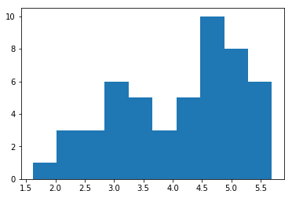

```python
plt.hist(df['Incongruent RT'])
```

Cool beans. We made a graph

### Labelling the x-axis

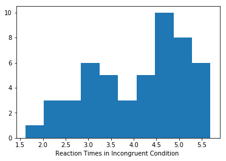

```python
plt.hist(df['Incongruent RT'])
plt.xlabel('Reaction Times in Incongruent Condition ')
```

### Labeling the y-axis

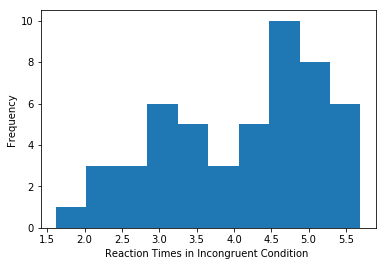

```python
plt.hist(df['Incongruent RT'])
plt.xlabel('Reaction Times in Incongruent Condition ')
plt.ylabel('Frequency')
```

What if we want to write something on the plot, like the mean and standard deviation?

First we caculate the values

```python
mean = df['Incongruent RT'].mean()
stdev = df['Incongruent RT'].std()
```

The plt.text function first takes the coordinates of where the text should be placed, and then takes the text to display.

- The coordinates are easy, they follow your axes
- To display special symbols like greek letters in matplotlib
  - surround the statement with dollar signs `$` and back slashes `\\`
  - We're technically using LaTeX here
  - you can google LaTeX in Jupyter Notebooks for more examples and help
- I'm also using string formatting here where `%s` inside quotes tells Python I'm using a string
  - Then outside the quotes, you put a `%`, and a tuple containing your variables.

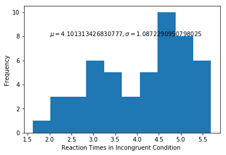

```python
plt.hist(df['Incongruent RT'])
plt.xlabel('Reaction Times in Incongruent Condition ')
plt.ylabel('Frequency')
plt.text(2, 8, r'$\mu=%s, \sigma=%s$'% (mean,stdev))
```

As you can see, it's sloppy. There are too many decimal places to look nice. Let's round our numbers and display again.

In science it's best not to round the actual variables, but to round the display of the variables. This ensures that when you are doing calculations, you are not accumulating errors and you always are using the most accurate data.

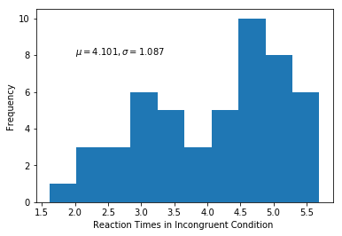

```python
plt.hist(df['Incongruent RT'])
plt.xlabel('Reaction Times in Incongruent Condition ')
plt.ylabel('Frequency')
plt.text(2, 8, r'$\mu=%s, \sigma=%s$'% (round(mean, 3),round(stdev, 3)))
```

### Grids

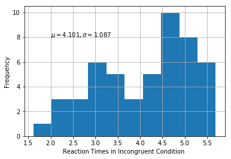

```python
plt.hist(df['Incongruent RT'])
plt.xlabel('Reaction Times in Incongruent Condition ')
plt.ylabel('Frequency')
plt.text(2, 8, r'$\mu=%s, \sigma=%s$'% (round(mean, 3),round(stdev, 3)))
plt.grid(True)
```

### Changing the axis limits

```
(0, 20)
```

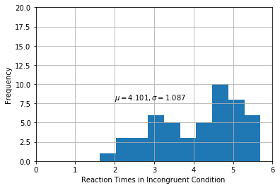

```python
plt.hist(df['Incongruent RT'])
plt.xlabel('Reaction Times in Incongruent Condition ')
plt.ylabel('Frequency')
plt.text(2, 8, r'$\mu=%s, \sigma=%s$'% (round(mean, 3),round(stdev, 3)))
plt.grid(True)
plt.xlim(0, 6)
plt.ylim(0, 20)
```

### Plot title

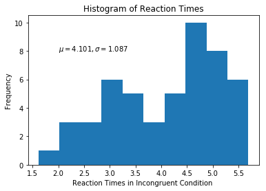

```python
plt.hist(df['Incongruent RT'])
plt.xlabel('Reaction Times in Incongruent Condition ')
plt.ylabel('Frequency')
plt.text(2, 8, r'$\mu=%s, \sigma=%s$'% (round(mean, 3),round(stdev, 3)))
plt.title('Histogram of Reaction Times')
```

### Plotting two varaibles on the same histogram

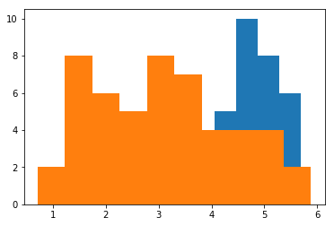

```python
plt.hist(df['Incongruent RT'])
plt.hist(df['Congruent RT'])
```

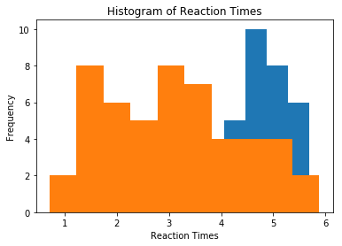

```python
plt.hist(df['Incongruent RT'])
plt.hist(df['Congruent RT'])
plt.xlabel('Reaction Times')
plt.ylabel('Frequency')
plt.title('Histogram of Reaction Times')
```

### The Legend of the Plot

First specify the labels for your legend in a list

```python
labels = ['Incongruent', 'Congruent']
```

Then apply the legend method

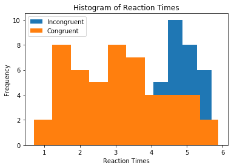

```python
plt.hist(df['Incongruent RT'])
plt.hist(df['Congruent RT'])
plt.xlabel('Reaction Times')
plt.ylabel('Frequency')
plt.title('Histogram of Reaction Times')
plt.legend(labels)
```

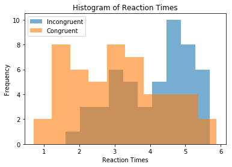

```python
plt.hist(df['Incongruent RT'], alpha = 0.6)
plt.hist(df['Congruent RT'], alpha = 0.6)
plt.xlabel('Reaction Times')
plt.ylabel('Frequency')
plt.title('Histogram of Reaction Times')
plt.legend(labels)
```

### Saving the figure

#### It is best to always use raw, uncompressed images

#### Data is lost and/or altered when compressing. You can always compress later.

Compressing is when you reduce the size of a file by rather than storing all of the pixel values, we store an equation that produces something similar. The more you compress, the more you mess it up.

[figure not shown]

For uncompressed images use `tiff` or `png` do not use `jpg`

#### To save our file we use the `savefig` method and specify our filename.

If you use the file extension, Python knows what format to save in automatically. You can get more complicated, but those are the basics

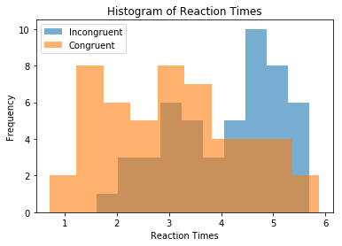

```python
plt.hist(df['Incongruent RT'], alpha = 0.6)
plt.hist(df['Congruent RT'], alpha = 0.6)
plt.xlabel('Reaction Times')
plt.ylabel('Frequency')
plt.title('Histogram of Reaction Times')
plt.legend(labels)
plt.savefig('reaction_times.png')
```

Here we can see the saved `reaction_times.png` file

[figure not shown]